# Who is the reference?

J. Ignacio Lucas Lledó

2024-10-21

Now that we have a reference set of ddRAD loci, independent of any reference genome assembly, we can add one individual to the analysis: the one whose whole genome was sequenced with Illumina reads with the aim of polishing a reference genome. Could it be that it is a hybrid? That would be funny, eh?

Let’s call it E716xxx, following the ddRAD-seq samples’ names format. The strategy is:

1. Map its shotgun Illumina reads to the ddRAD loci.
2. Repeat the whole population structure analysis with ANGSD including the new BAM file in the list.

## Mapping

The fragment lengths in E716xxx’s reads could be longer than those in the ddRAD-seq libraries. Thus, to map the shotgun reads to the RAD loci with default settings amounts to assume that RAD loci are longer than the fragment size in the E716xxx library. I don’t have that information, so the safest thing to do is to map forward and reverse reads as if they were not paired, but independent. Let’s see.

```bash
if [ ! -d BAM ]; then mkdir BAM; fi
if [ ! -e BAM/T165Cxa.bam.bai ]; then
   ln -t BAM ../2024-10-04/BAM/*
fi
if [ ! -e radloci.fa ]; then
   # It must be there:
   ln ../2024-10-04/radloci.fa ./radloci.fa
fi
if [ ! -e radloci.fa.fai ]; then
   samtools faidx radloci.fa
fi
if [ ! -e radloci.fa.bwt.2bit.64 ]; then
   if [ -e ../2024-10-04/radloci.fa.bwt.2bit.64 ]; then
      ln -t . ../2024-10-04/radloci.fa.*
   else
      bwa-mem2 index radloci.fa &> /dev/null
   fi
fi
if [ ! -e BAM/E716xxx.bam.bai ]; then
   if [ ! -e BAM/E716xxx.bam ]; then
      if [ ! -e BAM/E716xxx.sam ]; then
         bwa-mem2 mem -t 8 radloci.fa -U 0 -S \
            ../../data/Shotgun_Illumina/TrueSeqCrepi_1.fastq.gz \
            ../../data/Shotgun_Illumina/TrueSeqCrepi_2.fastq.gz \
            -R "@RG\tID:E716xxx\tSM:E716xxx" 1> BAM/E716xxx.sam 2> bwamem2.log
      fi
      samtools view -F 260 -f 2 -u BAM/E716xxx.sam | \
      samtools sort > BAM/E716xxx.bam
   fi
   samtools index BAM/E716xxx.bam
   if [ -e BAM/E716xxx.sam ]; then rm BAM/E716xxx.sam; fi
fi
```

## Likelihoods

Genotype likelihoods for all samples must be re-estimated, but the selection of sites is already done, one per locus. Selected sites must be in `../2024-10-05/Sites/ARCTIC_snp.sites`. Likelihood estimation with ANGSD will happen in a different computer, where I do not want to asume the same folder structure. To facilitate portability, all necessary files must be here. I include the script `angsd2.sbatch`, which will be submitted there, but could also be run in Thermomix, I think.

```bash
if [ ! -e Sites.txt ]; then
   ln ../2024-10-05/Sites/ARCTIC_snp.sites ./Sites.txt
fi

if [ ! -e BadGuys.txt ]; then
   ln ../2024-10-04/BadGuys.txt BadGuys.txt
fi

if [ ! -e ARCTIC.list ]; then
   ls -1 BAM/*.bam | grep -E "E|L|S" | grep -v -F -f BadGuys.txt > ARCTIC.list
fi
if ! grep -q E716xxx ARCTIC.list; then
   echo "E716xxx is missing from the list of samples."
   exit
fi
```

```bash
# This is not run here. See angsd2.sbatch for details.
if [ ! -e NGSadmix/K3.eval ]; then
   bash angsd2.sbatch
fi
```

## NGSadmix results

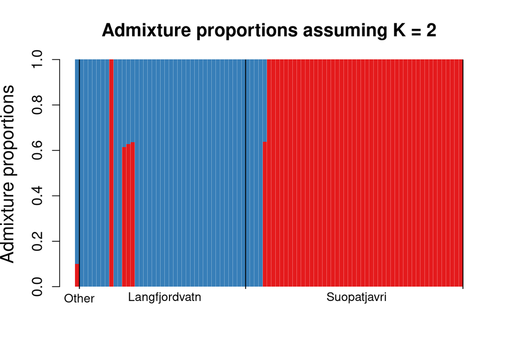

```r
source('/data/joiglu/bin/evalAdmix/visFuns.R')
MetaData <- read.table('../../data/IDs/Crepido_fish_IDs_all_data_2021Dec.txt')
IndNames <- gsub('(BAM/|.bam)', '',
                 scan('ARCTIC.list', what = 'character', quiet = TRUE))
MetaData <- MetaData[MetaData$P_code %in% IndNames, ]
row.names(MetaData) <- MetaData$P_code
Lake <- MetaData[IndNames, 'Lake']
# Individual E716xxx absent in MetaData, does not get a lake assigned.
Lake[is.na(Lake)] <- 'Other'
QK2 <- read.table('NGSadmix/K2.qopt')
QK3 <- read.table('NGSadmix/K3.qopt')
ord <- orderInds(pop = Lake, q = QK3)

plotAdmix(QK2, pop = Lake, ord = ord)
```

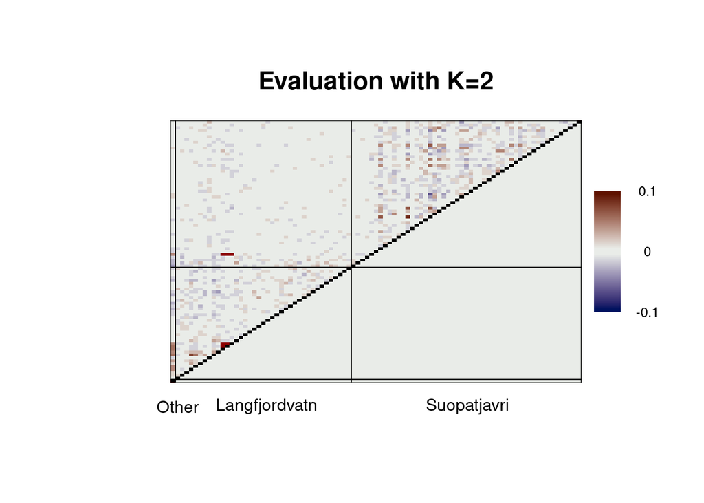

```r
r <- as.matrix(read.table('NGSadmix/K2.eval'))
plotCorRes(cor_mat = r, pop = Lake, ord = ord,
           title = 'Evaluation with K=2', min_z = -0.1,
           max_z = 0.1, cex.lab = 1,
           pop_labels = c(FALSE, TRUE), cex.legend = 0.8)
```

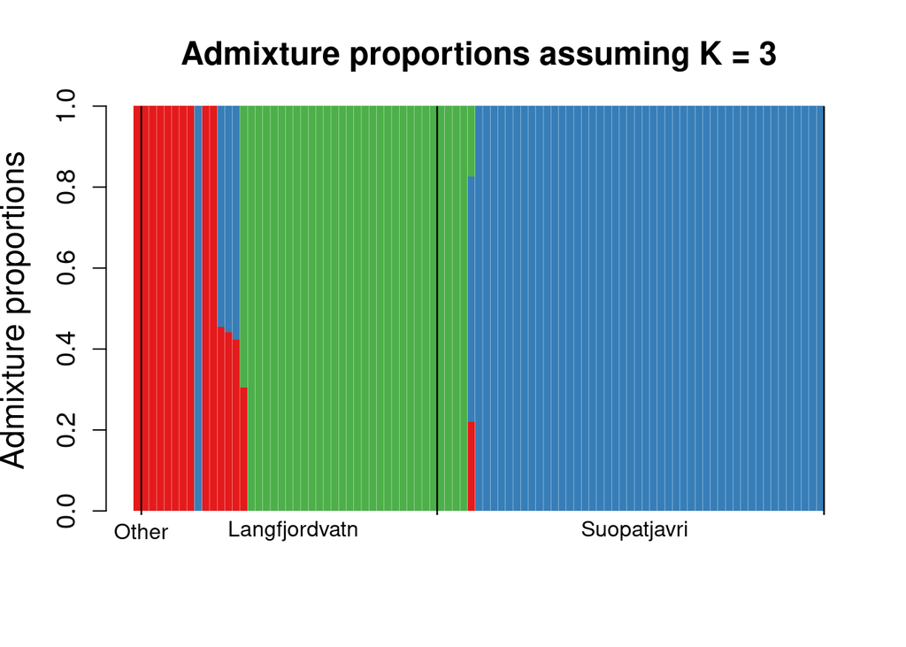

```r
plotAdmix(QK3, pop = Lake, ord = ord)
```

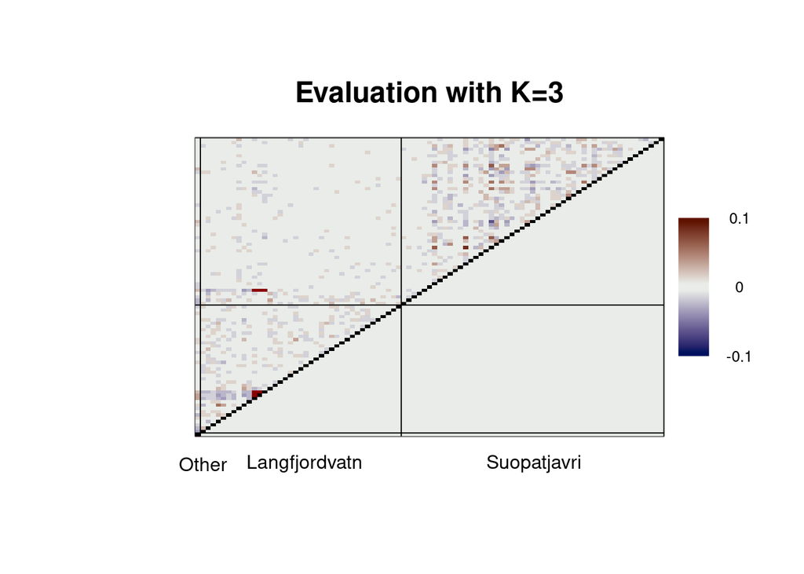

```r
r <- as.matrix(read.table('NGSadmix/K3.eval'))
plotCorRes(cor_mat = r, pop = Lake, ord = ord,
           title = 'Evaluation with K=3', min_z = -0.1,
           max_z = 0.1, cex.lab = 1,
           pop_labels = c(FALSE, TRUE), cex.legend = 0.8)
```

## PCangsd results

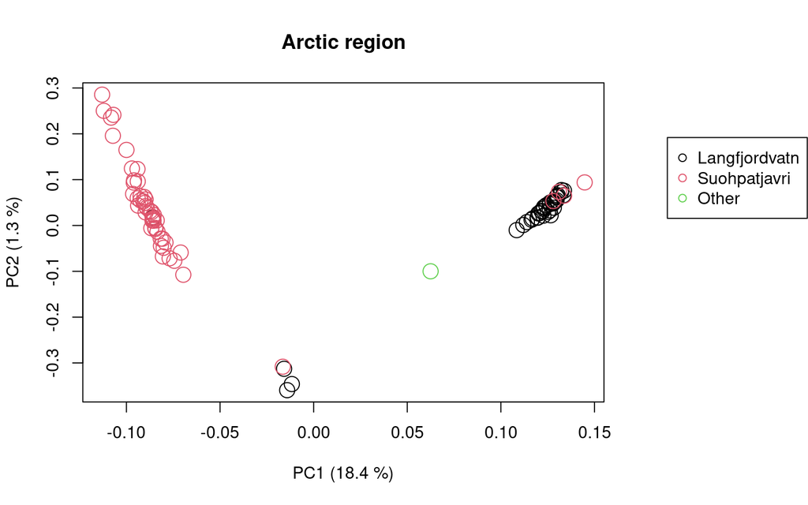

```r
IndNames <- gsub('(BAM/|.bam)', '',
                 scan('ARCTIC.list', what = 'character', quiet = TRUE))
Lake <- factor(Lake, levels = c('Langfjordvatn', 'Suopatjavri', 'Other'))
cov <- as.matrix(read.table('PCangsd/ARCTIC.cov'))
e   <- eigen(cov)
layout(matrix(1:2, ncol = 2), width = c(4, 1), height = c(1, 1))
plot(e$vectors[, c(1, 2)], col = Lake, pch = 1, cex = 2,
     xlab = sprintf('PC1 (%.1f %%)', 100 * e$values[1] / sum(e$values)),
     ylab = sprintf('PC2 (%.1f %%)', 100 * e$values[2] / sum(e$values)),
     main = 'Arctic region')
par(mar = c(0, 0, 4.1, 0))
plot(c(0, 1), c(0, 1), type = 'n', axes = FALSE, xlab = '', ylab = '')
legend(0.1, 0.9, c('Langfjordvatn', 'Suohpatjavri', 'Other'),
       col = 1:3, pch = 1, cex = 1)
```

```r
par(mar = c(5.1, 4.1, 4.1, 1))
```

## Conclusions

Being partially admixed means a few chromosomic regions are expected to be highly heterozygous. Definitely, not the best option for a reference. But most of its genome should be normal.